# Loss function for lasso-type estimators

`EAlasso` package is designed to facilitate simulation based inference of lasso type estimators. The package includes

- Computing the lasso type estimator
- Gaussian bootstrap and wild multiplier bootstrap sampler
- Importance sampler
- Metropolis-Hastings sampler for lasso estimator
- Post-selection inference for lasso estimator

## Loss function for lasso-type estimators

Let the unknown true model be \[ y = X\beta_0 + \epsilon,\] where \(\beta_0\) is unknown true coefficient and \(\epsilon_i \sim_{iid} N(0,\sigma^2)\).

We use following loss functions.

\[ \ell_{grlasso}(\beta ; \lambda) = \frac{1}{2}||y-X\beta||^2_2 + n\lambda\sum_j w_j||\beta_{(j)}||_2,\]

\[ \ell_{sgrlasso}(\beta, \sigma ; \lambda) = \frac{1}{2\sigma}||y-X\beta||^2_2 + \frac{\sigma}{2} + n\lambda\sum_j w_j||\beta_{(j)}||_2,\] where \(grlasso\) and \(sgrlasso\) represent group lasso and scaled group lasso, respectively, and \(w_j\) is the weight factor for the j-th group. Loss functions for lasso and scaled lasso can be treated as special cases of group lasso and group scaled lasso when the group size is one, respectively.

## Fit Lasso Type Estimator

`Lasso.MHLS` computes lasso, group lasso, scaled lasso, or scaled group lasso solution. Users can either provide the value of \(\lambda\) or choose to use cross-validation by setting `lbd = "cv.min"` or `lbd = "cv.1se"`.

```r
library(EAlasso)
set.seed(1234)
n <- 30; p <- 50
Niter <-  10
group <- rep(1:(p/5), each = 5)
weights <- rep(1, p/5)
beta0 <- c(rep(1,5), rep(0, p-5))
X <- matrix(rnorm(n*p), n)
Y <- X %*% beta0 + rnorm(n)
# set lambda = .5
Lasso.MHLS(X = X, Y = Y, lbd = .5, group = group, weights = weights, type="grlasso")
```

```
## $B0
##  [1]  0.5161790486  1.0188138710  0.6824656800  0.3931492014  0.6874913816
##  [6] -0.0016266183  0.0217197347  0.0301559820 -0.0099458388 -0.0164052833
## [11] -0.0014128000 -0.0045411093  0.0020861350  0.0005237965 -0.0052717513
## [16]  0.0000000000  0.0000000000  0.0000000000  0.0000000000  0.0000000000
## [21]  0.0000000000  0.0000000000  0.0000000000  0.0000000000  0.0000000000
## [26]  0.0000000000  0.0000000000  0.0000000000  0.0000000000  0.0000000000
## [31]  0.0000000000  0.0000000000  0.0000000000  0.0000000000  0.0000000000
## [36]  0.0000000000  0.0000000000  0.0000000000  0.0000000000  0.0000000000
## [41] -0.0017727886 -0.0011658229  0.0061202270  0.0010349847 -0.0028864100
## [46]  0.0000000000  0.0000000000  0.0000000000  0.0000000000  0.0000000000
##
## $S0
##  [1]  0.33335300  0.65800762  0.44078966  0.25391528  0.44402685
##  [6] -0.03887064  0.51894719  0.72052696 -0.23764121 -0.39196384
```

[output cut: 19 more lines]

```r
# use cross-validation
Lasso.MHLS(X = X, Y = Y, lbd = "cv.1se", group = group, weights = weights, type="grlasso")
```

```
## $B0
##  [1] 0.2585571 0.5662970 0.3423212 0.1790867 0.3370463 0.0000000 0.0000000
##  [8] 0.0000000 0.0000000 0.0000000 0.0000000 0.0000000 0.0000000 0.0000000
## [15] 0.0000000 0.0000000 0.0000000 0.0000000 0.0000000 0.0000000 0.0000000
## [22] 0.0000000 0.0000000 0.0000000 0.0000000 0.0000000 0.0000000 0.0000000
## [29] 0.0000000 0.0000000 0.0000000 0.0000000 0.0000000 0.0000000 0.0000000
## [36] 0.0000000 0.0000000 0.0000000 0.0000000 0.0000000 0.0000000 0.0000000
## [43] 0.0000000 0.0000000 0.0000000 0.0000000 0.0000000 0.0000000 0.0000000
## [50] 0.0000000
##
## $S0
##  [1]  0.320602395  0.702188669  0.424466295  0.222062148  0.417926070
##  [6] -0.082468001  0.277804834  0.096219513 -0.208633439 -0.139425260
## [11] -0.045785589 -0.085990641  0.311352839  0.011898386 -0.431104452
## [16]  0.434035899  0.080054001  0.099761761  0.383888228 -0.046916353
```

[output cut: 17 more lines]

## Parametric Bootstrap Sampler

`PBsampler` supports two bootstrap methods; Gaussian bootstrap and wild multiplier bootstrap. Due to the fact that the sampling distirbution of \((\hat{\beta}, S)\), coefficient estimator and its subgradient, is characterized by \((\beta_0, \sigma^2, \lambda)\), users are required to provide PE(either the estimate of \(\beta_0\) or the estimate of \(E(y) = X\beta_0\)), sig2(or estimate of \(\sigma^2\)) and lbd(\(\lambda\) from above loss functions).

By specifying two sets of arguments, (PE_1, sig2_1, lbd_1) and (PE_2, sig2_2, lbd_2), users can sample from the mixture distribution. In this way, samples will be drawn from (PE_1, sig2_1, lbd_1) with ½ probability and from (PE_2, sig2_2, lbd_2) with another ½ probability.

```r
set.seed(1234)
n <- 5; p <- 10
Niter <-  3
group <- rep(1:(p/5), each = 5)
weights <- rep(1, p/5)
beta0 <- c(rep(1,5), rep(0, p-5))
X <- matrix(rnorm(n*p), n)
Y <- X %*% beta0 + rnorm(n)
#
# Using non-mixture distribution
#
PBsampler(X = X, PE_1 = rep(0, p), sig2_1 = 1, lbd_1 = .5,
weights = weights, group = group, type = "grlasso", niter = Niter, parallel = FALSE)
```

```
## $beta
##           [,1]        [,2]         [,3]        [,4]       [,5]        [,6]
## [1,] -0.352558 -0.04509164 -0.163567850 -0.20739254 0.04094005  0.07980136
## [2,]  0.000000  0.00000000  0.000000000  0.00000000 0.00000000  0.19448453
## [3,] -0.101949 -0.01026838  0.007229023 -0.04528434 0.02612852 -0.48574043
##             [,7]         [,8]        [,9]       [,10]
## [1,]  0.01439087 -0.078904475 -0.01727025 -0.02585135
## [2,]  0.10015568 -0.449645799 -0.06019509 -0.11899434
## [3,] -0.02476162  0.004011741  0.16610299 -0.22672081
##
## $subgrad
##            [,1]        [,2]       [,3]       [,4]        [,5]       [,6]
## [1,] -0.7927653 -0.10136072 -0.3677447 -0.4663320  0.09208561  0.6801903
## [2,]  0.5445969  0.06272778 -0.4164824  0.2135554 -0.29673620  0.3758234
## [3,] -0.8845285 -0.08909017  0.0627215 -0.3928918  0.22669513 -0.8647087
##             [,7]         [,8]       [,9]      [,10]
## [1,]  0.12267491 -0.672507693 -0.1471783 -0.2203233
## [2,]  0.19353466 -0.868915638 -0.1163051 -0.2298749
## [3,] -0.04405268  0.007100924  0.2956503 -0.4035220
##
## $X
##            [,1]       [,2]        [,3]       [,4]       [,5]       [,6]
## [1,] -1.2070657  0.5060559 -0.47719270 -0.1102855  0.1340882 -1.4482049
## [2,]  0.2774292 -0.5747400 -0.99838644 -0.5110095 -0.4906859  0.5747557
## [3,]  1.0844412 -0.5466319 -0.77625389 -0.9111954 -0.4405479 -1.0236557
## [4,] -2.3456977 -0.5644520  0.06445882 -0.8371717  0.4595894 -0.0151383
## [5,]  0.4291247 -0.8900378  0.95949406  2.4158352 -0.6937202 -0.9359486
##            [,7]       [,8]       [,9]      [,10]
## [1,]  1.1022975 -1.1676193  1.4494963 -0.9685143
## [2,] -0.4755931 -2.1800396 -1.0686427 -1.1073182
## [3,] -0.7094400 -1.3409932 -0.8553646 -1.2519859
## [4,] -0.5012581 -0.2942939 -0.2806230 -0.5238281
## [5,] -1.6290935 -0.4658975 -0.9943401 -0.4968500
##
## $PE
##  [1] 0 0 0 0 0 0 0 0 0 0
##
## $sig2
## [1] 1
##
```

[output cut: 15 more lines]

```
## $Btype
## [1] "gaussian"
##
## $Y
## NULL
##
## $mixture
## [1] FALSE
##
## $call
## PBsampler(X = X, PE_1 = rep(0, p), sig2_1 = 1, lbd_1 = 0.5, weights = weights,
##     group = group, niter = Niter, type = "grlasso", parallel = FALSE)
##
## attr(,"class")
## [1] "PB"
```

```r
#
# Using mixture distribution
#
PBsampler(X = X, PE_1 = rep(0, p), sig2_1 = 1, lbd_1 = .5,
 PE_2 = rep(1, p), sig2_2 = 2, lbd_2 = .3, weights = weights,
 group = group, type = "grlasso", niter = Niter, parallel = FALSE)
```

```
## $beta
##            [,1]       [,2]        [,3]       [,4]        [,5]        [,6]
## [1,]  0.0000000  0.0000000  0.00000000  0.0000000  0.00000000 -0.27037255
## [2,] -0.3321438 -0.3335285 -0.04146113 -0.4657323  0.06207898 -0.08107893
## [3,]  1.2725252  0.7146599  0.26386786  0.7719070 -0.07763173  0.28132410
##            [,7]       [,8]       [,9]      [,10]
## [1,]  0.1244791 -0.1583272  0.2244446 -0.1545523
## [2,] -0.3907521 -0.0850889 -0.3701505 -0.2274157
## [3,]  1.2571473  1.5687074  1.1992639  1.4817464
##
## $subgrad
##            [,1]       [,2]        [,3]       [,4]        [,5]       [,6]
## [1,] -0.6154901  0.1204292 -0.02635645  0.1638249  0.05509270 -0.6236786
## [2,] -0.4984376 -0.5005101 -0.06220821 -0.6989211  0.09316983 -0.1360256
## [3,]  0.7602475  0.4269253  0.15763120  0.4611596 -0.04639609  0.1009190
##            [,7]       [,8]       [,9]      [,10]
## [1,]  0.2870946 -0.3652390  0.5178028 -0.3565144
## [2,] -0.6555996 -0.1427020 -0.6210599 -0.3816486
## [3,]  0.4514964  0.5632223  0.4306009  0.5323561
##
## $X
##            [,1]       [,2]        [,3]       [,4]       [,5]       [,6]
## [1,] -1.2070657  0.5060559 -0.47719270 -0.1102855  0.1340882 -1.4482049
## [2,]  0.2774292 -0.5747400 -0.99838644 -0.5110095 -0.4906859  0.5747557
## [3,]  1.0844412 -0.5466319 -0.77625389 -0.9111954 -0.4405479 -1.0236557
## [4,] -2.3456977 -0.5644520  0.06445882 -0.8371717  0.4595894 -0.0151383
## [5,]  0.4291247 -0.8900378  0.95949406  2.4158352 -0.6937202 -0.9359486
##            [,7]       [,8]       [,9]      [,10]
## [1,]  1.1022975 -1.1676193  1.4494963 -0.9685143
## [2,] -0.4755931 -2.1800396 -1.0686427 -1.1073182
## [3,] -0.7094400 -1.3409932 -0.8553646 -1.2519859
## [4,] -0.5012581 -0.2942939 -0.2806230 -0.5238281
## [5,] -1.6290935 -0.4658975 -0.9943401 -0.4968500
##
## $PE
##      [,1] [,2] [,3] [,4] [,5] [,6] [,7] [,8] [,9] [,10]
## PE_1    0    0    0    0    0    0    0    0    0     0
## PE_2    1    1    1    1    1    1    1    1    1     1
##
## $sig2
```

[output cut: 18 more lines]

```
## [1] "gaussian"
##
## $Y
## NULL
##
## $mixture
## [1] TRUE
##
## $call
## PBsampler(X = X, PE_1 = rep(0, p), sig2_1 = 1, lbd_1 = 0.5, PE_2 = rep(1,
##     p), sig2_2 = 2, lbd_2 = 0.3, weights = weights, group = group,
##     niter = Niter, type = "grlasso", parallel = FALSE)
##
## attr(,"class")
## [1] "PB"
```

## Importance Sampler for High Dimensional Data

Importance Sampler enables users to access the inference of an extreme region. This is done by using a proposal distiribution that is denser around the extreme region.

Say that we are interested in computing the expectation of a function of ㅁ random variable, \(h(X)\). Let \(f(x)\) be the true or target distribution and \(g(x)\) be the proposal distribution. We can approximate the expectation by a weighted average of samples drawn from the proposal distribution as follows,

\[ \begin{eqnarray} E_f\Big[h(X)\Big] &=& E_g \Big[h(X)\frac{f(X)}{g(X)} \Big]\ &\approx& \frac{1}{N}\sum_{i=1}^N h(x_i)\frac{f(x_i)}{g(x_i)}. \end{eqnarray} \] By using `hdIS` method, one can easily compute the importance weight which is the ratio of target density over proposal density; \(f(x_i)/g(x_i)\) from above equation.

Users can simply draw samples from the proposal distribution using `PBsampler` and plug in the result into `hdIS` with target distribution parameters in order to compute the importance weights.

```r
# Target distribution parameter
PETarget <- rep(0, p)
sig2Target <- .5
lbdTarget <- .37
# Proposal distribution parameter
PEProp1 <- rep(1, p)
sig2Prop1 <- .5
lbdProp1 <- 1

# Draw samples from proposal distribution
PB <- PBsampler(X = X, PE_1 = PEProp1, sig2_1 = sig2Prop1,
 lbd_1 = lbdProp1, weights = weights, group = group, niter = Niter,
 type="grlasso", PEtype = "coeff")

# Compute importance weights
hdIS(PB, PETarget = PETarget, sig2Target = sig2Target, lbdTarget = lbdTarget,
log = TRUE)
```

```
## [1]  -96.45898 -126.87436  -69.81876
```

## Metropolis-Hastings Lasso Sampler

In this section, we introduce `MHLS` method, a Markov Chain Monte Carlo(MCMC) sampler for lasso estimator. Although bootstrapping is one of the most convenient sampling methods, it has a clear limitation which is that sampling from the conditional distribution is impossible. In contrast, MCMC sampler can easily draw samples from the conditional distribution. Here, we introduce `MHLS` function which draws lasso samples under the fixed active set, A.

```r
weights <- rep(1,p)
lbd <- .37
LassoResult <- Lasso.MHLS(X = X,Y = Y,lbd = lbd, type = "lasso", weights = weights)
B0 <- LassoResult$B0
S0 <- LassoResult$S0
Result <- MHLS(X = X, PE = B0, sig2 = 1, lbd = 1,
    weights = weights, B0 = B0, S0 = S0, niter = 100, burnin = 0,
    PEtype = "coeff")
Result
```

```
## ===========================
## Number of iteration:  100
##
## Burn-in period:  0
##
## Plug-in PE:
##  [1] 0.7996404 0.0000000 0.0000000 0.9604899 0.0000000 0.0000000 0.0000000
##  [8] 0.8464680 0.0000000 0.6133309
## PEtype:
## [1] "coeff"
##
## Last 10 steps of beta's:
##            [,1] [,2] [,3]       [,4] [,5] [,6] [,7]      [,8] [,9]
##  [1,] 0.2301647    0    0 0.87494288    0    0    0 1.1372482    0
##  [2,] 0.2216513    0    0 0.87494288    0    0    0 1.1372482    0
##  [3,] 0.2216513    0    0 0.87494288    0    0    0 1.1372482    0
##  [4,] 0.2216513    0    0 0.87494288    0    0    0 0.5261399    0
##  [5,] 0.2216513    0    0 0.87494288    0    0    0 0.9507334    0
##  [6,] 0.2216513    0    0 0.02764955    0    0    0 0.9507334    0
##  [7,] 0.2216513    0    0 0.02764955    0    0    0 0.9507334    0
##  [8,] 0.2216513    0    0 0.02764955    0    0    0 0.9507334    0
##  [9,] 0.2216513    0    0 0.02764955    0    0    0 0.6510129    0
## [10,] 0.2216513    0    0 0.02764955    0    0    0 0.6510129    0
##           [,10]
##  [1,] 0.0266313
##  [2,] 0.0266313
##  [3,] 0.0266313
##  [4,] 0.0266313
##  [5,] 0.0266313
##  [6,] 0.0266313
##  [7,] 0.0266313
##  [8,] 0.0266313
##  [9,] 0.1242664
## [10,] 0.1665691
##
## last 10 steps of subgradients:
##           [,1]       [,2]      [,3]     [,4]        [,5]      [,6]
##  [1,] 0.999974 0.13759060 0.5547765 1.000005 -0.14332418 0.8796375
##  [2,] 0.999974 0.01943993 0.5885919 1.000005 -0.16374688 0.9878373
##  [3,] 0.999974 0.16053441 0.5482099 1.000005 -0.13935827 0.8586260
```

[output cut: 10 more lines]

```
##  [3,] -0.09361174 0.9998009 -0.19240099     1
##  [4,] -0.09361174 0.9998009 -0.19240099     1
##  [5,] -0.09361174 0.9998009 -0.19240099     1
##  [6,] -0.09361174 0.9998009 -0.19240099     1
##  [7,]  0.26216188 0.9998009  0.20176213     1
##  [8,]  0.16778094 0.9998009  0.09719708     1
##  [9,]  0.18624651 0.9998009  0.11765516     1
## [10,]  0.35270192 0.9998009  0.30207183     1
##
## Acceptance rate:
## -----------------------------
##           beta    subgrad
## # Accepted    :   132     60
## # Moved       :   396     99
## Acceptance rate   :   0.333   0.606
```

We provide summary and plot functions for `MHLS` results.

```r
summary(Result)
```

```
## $beta
##            mean    median       s.d       2.5%    97.5%
##  [1,] 0.4755451 0.4372553 0.2698570 0.12979384 0.980702
##  [2,] 0.0000000 0.0000000 0.0000000 0.00000000 0.000000
##  [3,] 0.0000000 0.0000000 0.0000000 0.00000000 0.000000
##  [4,] 0.5436983 0.6418675 0.3635998 0.02764955 1.255772
##  [5,] 0.0000000 0.0000000 0.0000000 0.00000000 0.000000
##  [6,] 0.0000000 0.0000000 0.0000000 0.00000000 0.000000
##  [7,] 0.0000000 0.0000000 0.0000000 0.00000000 0.000000
##  [8,] 0.5739825 0.5510263 0.3128277 0.03936662 1.137248
##  [9,] 0.0000000 0.0000000 0.0000000 0.00000000 0.000000
## [10,] 0.4601859 0.5169652 0.3061058 0.02663130 1.076506
##
## $subgradient
##              mean      median        s.d        2.5%       97.5%
##  [1,]  0.99997396  0.99997396 0.00000000  0.99997396  0.99997396
##  [2,]  0.31749093  0.32509546 0.17304436  0.02216915  0.65604207
##  [3,]  0.50328804  0.50111158 0.04952629  0.40639275  0.58781083
##  [4,]  1.00000533  1.00000533 0.00000000  1.00000533  1.00000533
##  [5,] -0.11222786 -0.11091339 0.02991125 -0.16327513 -0.05370826
##  [6,]  0.71488874  0.70792468 0.15847020  0.40485109  0.98533790
##  [7,]  0.14935391  0.16112558 0.26786932 -0.30779850  0.67342454
##  [8,]  0.99980093  0.99980093 0.00000000  0.99980093  0.99980093
##  [9,]  0.07678169  0.08982358 0.29677357 -0.42969943  0.65740180
## [10,]  1.00000000  1.00000000 0.00000000  1.00000000  1.00000000
##
## attr(,"class")
## [1] "summary.MHLS"
```

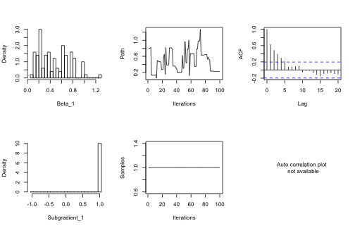

```
## Hit <Return> to see the next plot:
```

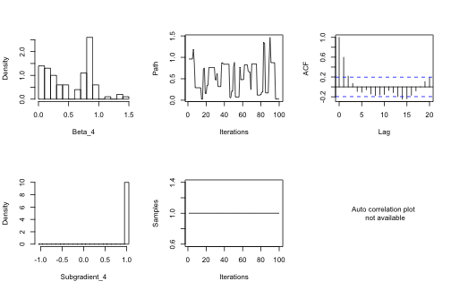

```
## Hit <Return> to see the next plot:
```

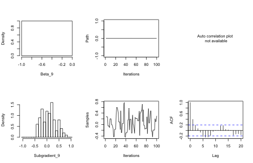

```
## Hit <Return> to see the next plot:
```

```r
plot(Result, index=c(1,4,9))
```

## Post-selection Inference

`Postinference.MHLS` is a method for post-selection inference. The inference is provided by `MHLS` results from multiple chains. In order to make the method more robust, different PE values are used for each chain. After drawing samples of \((\hat{\beta}, S)\) from MH sampler, we then refit the estimator to remove the bias of the lasso estimator. The final output will be the \((1-a)\) quantile of each active coefficient.

```r
Postinference.MHLS(X = X, Y = Y, lbd = lbd, sig2.hat = 1, alpha = .05,
 nChain = 5, niterPerChain = 20, parallel = !(.Platform$OS.type == "windows"))
```

```
##                 beta1       beta4      beta8    beta10
## LowerBound 0.06418462 -0.04510174 -0.9144653 0.9192836
## UpperBound 1.67117889  1.27691620  0.8988052 2.3979679
```